# NYPD_Shooting_Incident_Data

Kraynev Dmitry

2024-08-07

# **NYPD Shooting Incident Data (Historic)**

To begin analyzing the NYPD Shooting Incident Data (Historic), we’ll first import the data, clean it up as necessary, and then perform some exploratory data analysis. This will include creating visualizations and building a model to understand patterns

## Step 1. Data Import

Load the data

```
## # A tibble: 6 × 21
##   INCIDENT_KEY OCCUR_DATE OCCUR_TIME BORO      LOC_OF_OCCUR_DESC PRECINCT
##          <dbl> <chr>      <time>     <chr>     <chr>                <dbl>
## 1    244608249 05/05/2022 00:10      MANHATTAN INSIDE                  14
## 2    247542571 07/04/2022 22:20      BRONX     OUTSIDE                 48
## 3     84967535 05/27/2012 19:35      QUEENS    <NA>                   103
## 4    202853370 09/24/2019 21:00      BRONX     <NA>                    42
## 5     27078636 02/25/2007 21:00      BROOKLYN  <NA>                    83
## 6    230311078 07/01/2021 23:07      MANHATTAN <NA>                    23
## # ℹ 15 more variables: JURISDICTION_CODE <dbl>, LOC_CLASSFCTN_DESC <chr>,
## #   LOCATION_DESC <chr>, STATISTICAL_MURDER_FLAG <lgl>, PERP_AGE_GROUP <chr>,
## #   PERP_SEX <chr>, PERP_RACE <chr>, VIC_AGE_GROUP <chr>, VIC_SEX <chr>,
## #   VIC_RACE <chr>, X_COORD_CD <dbl>, Y_COORD_CD <dbl>, Latitude <dbl>,
## #   Longitude <dbl>, Lon_Lat <chr>
```

## Step 2: Data Cleaning

```
## # A tibble: 6 × 21
##   INCIDENT_KEY OCCUR_DATE OCCUR_TIME BORO      LOC_OF_OCCUR_DESC PRECINCT
##          <dbl> <date>     <Period>   <chr>     <chr>                <dbl>
## 1    244608249 2022-05-05 10M 0S     MANHATTAN INSIDE                  14
## 2    247542571 2022-07-04 22H 20M 0S BRONX     OUTSIDE                 48
## 3    254911480 2022-11-30 21H 15M 0S BRONX     OUTSIDE                 46
## 4    249623757 2022-08-15 18H 21M 0S QUEENS    OUTSIDE                101
## 5    243433246 2022-04-10 17H 0M 0S  BRONX     OUTSIDE                 49
## 6    253757468 2022-11-07 11H 35M 0S BROOKLYN  OUTSIDE                 75
## # ℹ 15 more variables: JURISDICTION_CODE <dbl>, LOC_CLASSFCTN_DESC <chr>,
## #   LOCATION_DESC <chr>, STATISTICAL_MURDER_FLAG <lgl>, PERP_AGE_GROUP <chr>,
## #   PERP_SEX <chr>, PERP_RACE <chr>, VIC_AGE_GROUP <chr>, VIC_SEX <chr>,
## #   VIC_RACE <chr>, X_COORD_CD <dbl>, Y_COORD_CD <dbl>, Latitude <dbl>,
## #   Longitude <dbl>, Lon_Lat <chr>
```

## Step 3 Exploratory Data Analysis (EDA)

Now we can perform some basic analysis to better understand the characteristics of the data. We will focus on the following aspects:

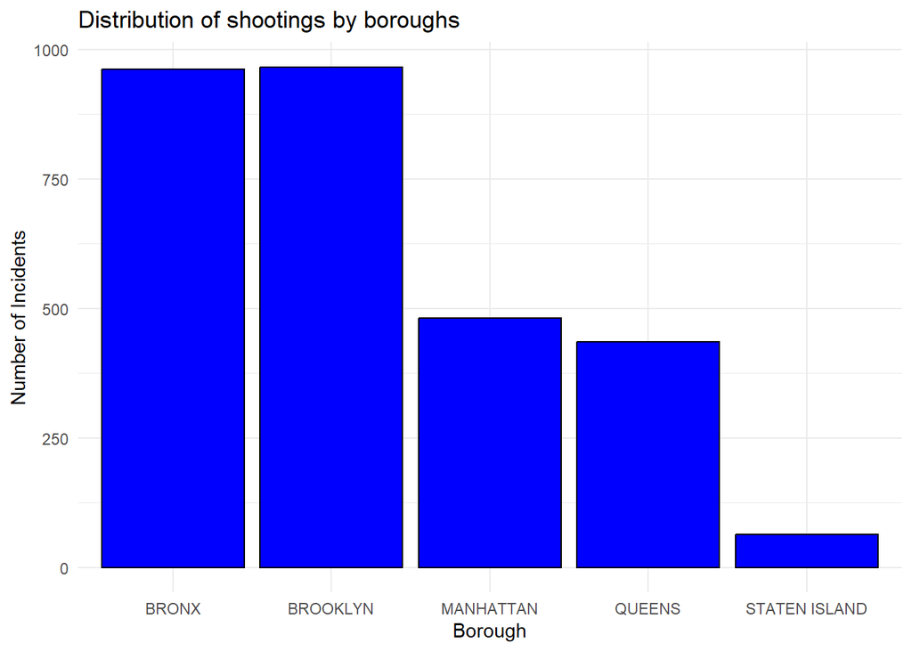

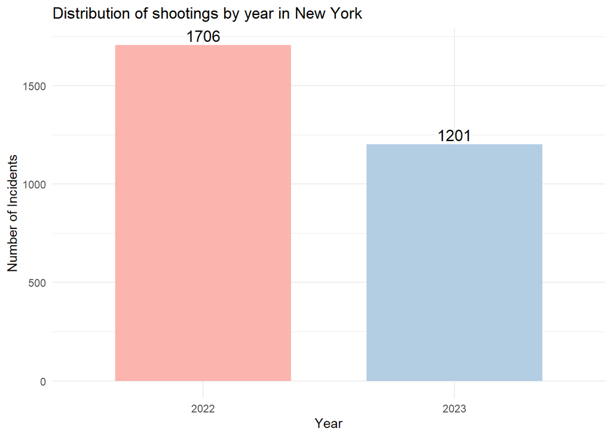

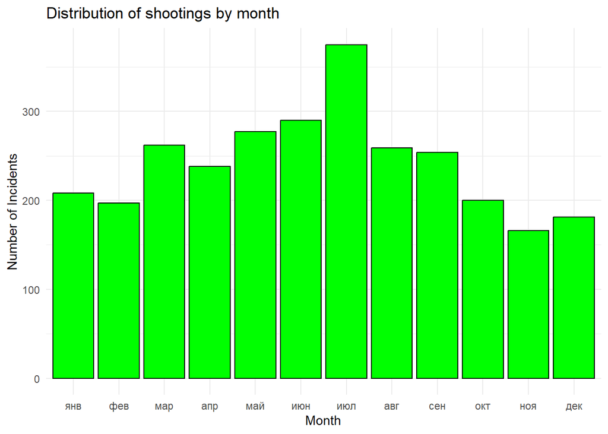

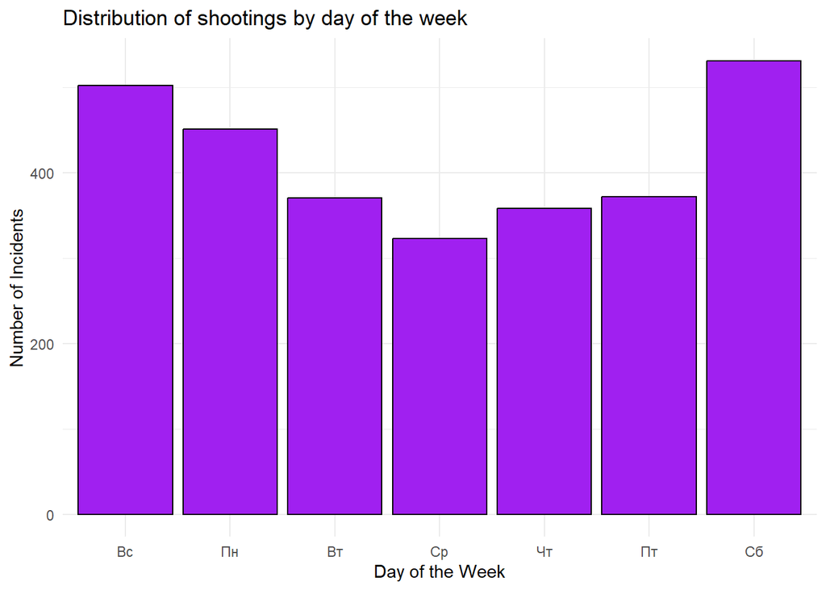

## Step 4: Building the Model

For modeling, logistic regression can be used to predict the probability of a shooting resulting in a homicide, using available factors such as borough, time of day, and others.

```
## [1]  0 22 21 18 17 11
```

```
##
## Call:
## glm(formula = murder ~ BORO + hour + PERP_RACE, family = "binomial",
##     data = model_data)
##
## Coefficients:
##                                     Estimate Std. Error z value Pr(>|z|)
## (Intercept)                        -1.839145   0.136564 -13.467  < 2e-16 ***
## BOROBROOKLYN                       -0.072631   0.116750  -0.622 0.533867
## BOROMANHATTAN                      -0.127694   0.139655  -0.914 0.360533
## BOROQUEENS                         -0.224405   0.150400  -1.492 0.135685
## BOROSTATEN ISLAND                   0.097539   0.318741   0.306 0.759594
## hour                                0.013108   0.005997   2.186 0.028840 *
## PERP_RACEASIAN / PACIFIC ISLANDER   0.689056   0.450229   1.530 0.125903
## PERP_RACEBLACK                      0.514890   0.109425   4.705 2.53e-06 ***
## PERP_RACEBLACK HISPANIC             0.703600   0.189882   3.705 0.000211 ***
## PERP_RACEUNKNOWN                  -10.743411 324.743727  -0.033 0.973609
## PERP_RACEWHITE                     -0.283439   0.624419  -0.454 0.649883
## PERP_RACEWHITE HISPANIC             0.778225   0.150747   5.162 2.44e-07 ***
## ---
## Signif. codes:  0 '***' 0.001 '**' 0.01 '*' 0.05 '.' 0.1 ' ' 1
##
## (Dispersion parameter for binomial family taken to be 1)
##
##     Null deviance: 2943.9  on 2906  degrees of freedom
## Residual deviance: 2893.3  on 2895  degrees of freedom
## AIC: 2917.3
##
## Number of Fisher Scoring iterations: 11
```

## Step 5: Interpretation of results

The output from the logistic regression model provides insights into the relationship between the probability of a shooting incident being classified as a murder and several predictor variables such as borough, hour of the incident, and perpetrator’s race. Here is a detailed interpretation of the model’s coefficients:

### Interpretation of Coefficients:

- **(Intercept):** The intercept term (-1.839145) represents the log odds of a shooting incident being classified as a murder when all other predictor variables are zero. The statistical significance (p < 0.001) indicates a strong baseline effect in the data.
- **Borough Coefficients:**
  - **BOROBROOKLYN, BOROMANHATTAN, BOROQUEENS, BOROSTATEN ISLAND:** These coefficients represent the log odds of a murder in these boroughs compared to the baseline borough (Bronx). None of these borough coefficients are statistically significant (p > 0.05), suggesting that, after controlling for other factors, there is no strong evidence of differences in the log odds of a murder across these boroughs compared to the Bronx.
- **hour:** The coefficient for hour (0.013108) indicates a small increase in the log odds of a shooting being a murder for each additional hour of the day, with a p-value of 0.028840, suggesting this effect is statistically significant at the 5% level.
- **Perpetrator Race Coefficients:**
  - **PERP_RACEASIAN / PACIFIC ISLANDER, PERP_RACEBLACK, PERP_RACEBLACK HISPANIC, PERP_RACEUNKNOWN, PERP_RACEWHITE, PERP_RACEWHITE HISPANIC:** These coefficients compare the log odds of a shooting being a murder for perpetrators of each race compared to the reference category (likely another race not listed). Significant p-values for BLACK (p < 0.001) and WHITE HISPANIC (p < 0.001) races indicate that shootings involving these racial groups are significantly more likely to be classified as murders compared to the reference racial group. The extremely large coefficient and standard error for PERP_RACEUNKNOWN suggest instability in this estimate, likely due to very few or no observations in this category.

### Conclusions:

The model suggests that the hour of the incident and certain racial categories of the perpetrator are significant predictors of whether a shooting incident is classified as a murder, after controlling for the borough of the incident. The lack of significant effects for most boroughs suggests that, within the context of this model, borough may not be a strong predictor of the incident being classified as a murder compared to other factors such as the time of the incident and the race of the perpetrator.

## Number of shootings by boroughs in New York

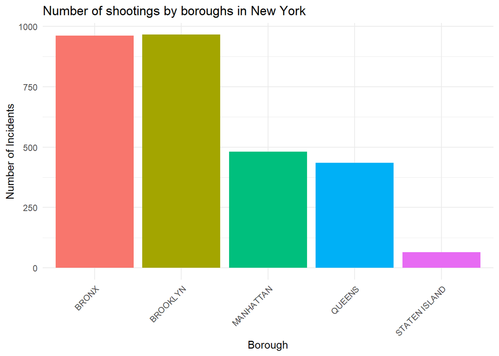

## Step 6. Bias Identification

Identifying potential biases in the dataset and the analysis is crucial for ensuring the validity and reliability of the findings. Here are some possible sources of bias that could affect the dataset and subsequent analysis:

1. **Reporting Bias**: There might be inconsistencies in how incidents are reported across different boroughs or precincts. Some areas might have higher reporting rates due to more active community policing, better public awareness, or more surveillance. This could lead to an overrepresentation of incidents in these areas.
2. **Selection Bias**: The data might not be representative of all shooting incidents. For example, if the dataset primarily includes incidents that were reported to the police or covered in the media, it may omit unreported cases, which could skew the analysis.
3. **Measurement Bias**: The accuracy of the data entries, such as the exact time of incidents or the classification of incidents as homicides, could be prone to human error or subjective judgment by the reporting officer.
4. **Geographical Bias**: The dataset might cover some geographical areas more thoroughly than others, possibly overlooking rural or less populated areas in favor of urban centers.
5. **Temporal Bias**: The data might reflect certain time periods more than others. For instance, if data collection was more rigorous in recent years, earlier years might be underrepresented, leading to an inaccurate trend analysis over time.
6. **Socioeconomic Bias**: Incidents might be more frequently or thoroughly reported in certain socioeconomic areas due to varying levels of police presence or community response.

Discussing and addressing these potential biases is essential for interpreting the results accurately and for making informed decisions based on the analysis.